# PA1_template

# 3. Average daily activity pattern

## a. Average steps taken

```r
library(dplyr)
interval <- data %>%
  filter(!is.na(steps)) %>%
  group_by(interval) %>%
  summarize(steps = mean(steps))
```

## b. Times series plot

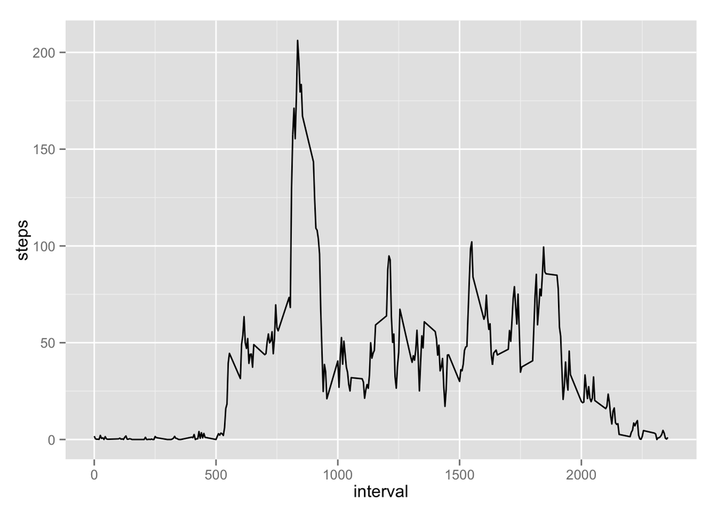

```r
library(ggplot2)
ggplot(interval, aes(x=interval, y=steps)) +
  geom_line(color = "black")
```

## c. Which 5-minute interval, on average across all the days in the dataset, contains the maximum number of steps?

```r
interval[which.max(interval$steps),]
```

```
## Source: local data frame [1 x 2]
##
##   interval    steps
##      (int)    (dbl)
## 1      835 206.1698
```

# 4. Imputing missing values

## a. Calculate and report the total number of missing values in the dataset

```r
sum(is.na(data$steps))
```

```
## [1] 2304
```

## b. Fill in all of the missing values in the dataset

Fill in the missing values with the mean number of steps in the 5-minutes interval

## c. Create a new dataset that is equal to the original dataset but with the missing data filled in

```r
data_full <- data
nas <- is.na(data_full$steps)
avg_interval <- tapply(data_full$steps, data_full$interval, mean, na.rm=TRUE, simplify=TRUE)
data_full$steps[nas] <- avg_interval[as.character(data_full$interval[nas])]
```

### Proof that all missing values have been filled in

```r
sum(is.na(data_full$steps))
```

```
## [1] 0
```

```r
library(dplyr)
steps_full <- data_full %>%
  filter(!is.na(steps)) %>%
  group_by(date) %>%
  summarize(steps = sum(steps)) %>%
        print
```

```
## Source: local data frame [61 x 2]
##
##          date    steps
##        (time)    (dbl)
## 1  2012-10-01 10766.19
## 2  2012-10-02   126.00
## 3  2012-10-03 11352.00
## 4  2012-10-04 12116.00
## 5  2012-10-05 13294.00
## 6  2012-10-06 15420.00
## 7  2012-10-07 11015.00
## 8  2012-10-08 10766.19
## 9  2012-10-09 12811.00
## 10 2012-10-10  9900.00
## ..        ...      ...
```